# Hubway Analysis

## Business Understanding

Bike sharing programs such as Hubway has become more and more common in major cities in the world, as it reduces pollution, and provides people a cheap way to go from one place to another without having to worry about storage and locking of their own bikes. To make such a program more efficient, we need to try to predict how long a person will take to return the bike, and what kind of user uses the bike, whether it’s a monthly or yearly subscriber, or a regular customer with a day pass.

```r
library(RMySQL)
library(gmodels)
library(class)
library(caret)
```

Set up connection for MySQL

```r
con <- dbConnect(MySQL(),
         user="root", password="alan980820",
         dbname="Hubway", host="localhost")
```

Query to retrieve trip data from the database, combining it with the google distance matrix data and the station data

```r
data <- dbSendQuery(con, "SELECT starttime, stoptime, startstation, s1.stationname AS startname, s1.longitude AS startlongitude, s1.latitude AS startlatitude, endstation, s2.stationname AS endname, s2.longitude AS endlongitude, s2.latitude AS endlatitude, bikeid, customer, subscriber, birthyear, gender, Trips.duration AS tripduration, Google.duration AS gduration, shortestdistance AS gdist
    FROM Trips
        JOIN Stations s1 ON Trips.startstation = s1.id
        JOIN Stations s2 ON Trips.endstation = s2.id
        JOIN Google ON Trips.id = Google.id
    WHERE Google.duration > 0 AND startstation != endstation;")
```

```
Decimal MySQL column 4 imported as numericDecimal MySQL column 5 imported as numericDecimal MySQL column 8 imported as numericDecimal MySQL column 9 imported as numeric
```

Fetch the result from the query

```r
df <- dbFetch(data, n=-1)
```

Check to make sure that the dataframe contains information that we need

```r
summary(df)
```

```
  starttime           stoptime          startstation     startname         startlongitude
 Length:61424       Length:61424       Min.   :  1.00   Length:61424       Min.   :-71.17
 Class :character   Class :character   1st Qu.: 42.00   Class :character   1st Qu.:-71.10
 Mode  :character   Mode  :character   Median : 80.00   Mode  :character   Median :-71.09
                                       Mean   : 90.41                      Mean   :-71.09
                                       3rd Qu.:130.00                      3rd Qu.:-71.07
                                       Max.   :232.00                      Max.   :-71.01
 startlatitude     endstation      endname           endlongitude     endlatitude
 Min.   :42.30   Min.   :  1.0   Length:61424       Min.   :-71.17   Min.   :42.30
 1st Qu.:42.35   1st Qu.: 41.0   Class :character   1st Qu.:-71.10   1st Qu.:42.35
 Median :42.36   Median : 78.0   Mode  :character   Median :-71.09   Median :42.36
 Mean   :42.36   Mean   : 89.9                      Mean   :-71.09   Mean   :42.36
 3rd Qu.:42.37   3rd Qu.:130.0                      3rd Qu.:-71.07   3rd Qu.:42.37
 Max.   :42.40   Max.   :228.0                      Max.   :-71.01   Max.   :42.40
     bikeid        customer         subscriber      birthyear             gender
 Min.   :   1   Min.   :0.00000   Min.   :0.0000   Length:61424       Min.   :1.000
 1st Qu.: 526   1st Qu.:0.00000   1st Qu.:1.0000   Class :character   1st Qu.:1.000
 Median :1006   Median :0.00000   Median :1.0000   Mode  :character   Median :1.000
 Mean   :1027   Mean   :0.06356   Mean   :0.9364                      Mean   :1.229
 3rd Qu.:1628   3rd Qu.:0.00000   3rd Qu.:1.0000                      3rd Qu.:1.000
 Max.   :2004   Max.   :1.00000   Max.   :1.0000                      Max.   :2.000
  tripduration       gduration          gdist
 Min.   :   62.0   Min.   :  15.0   Min.   :   87
 1st Qu.:  352.0   1st Qu.: 338.0   1st Qu.: 1356
 Median :  563.0   Median : 532.0   Median : 2072
 Mean   :  732.2   Mean   : 623.9   Mean   : 2524
 3rd Qu.:  920.0   3rd Qu.: 823.0   3rd Qu.: 3305
 Max.   :16654.0   Max.   :3630.0   Max.   :14134
```

Convert bikeid and station ids, birth year, and start and end station names to factor Also changing the time from character to POSIXct

```r
df$bikeid <- as.factor(df$bikeid)
df$startstation <- as.factor(df$startstation)
df$endstation <- as.factor(df$endstation)
df$startname <- as.factor(df$startname)
df$endname <- as.factor(df$endname)
df$birthyear <- as.factor(df$birthyear)
df$customer <- as.factor(df$customer)
df$subscriber <- as.factor(df$subscriber)
df$starttime <- as.POSIXct(df$starttime)
df$stoptime <- as.POSIXct(df$stoptime)
```

```r
summary(df)
```

```
   starttime                      stoptime                    startstation                                     startname     startlongitude
 Min.   :2018-03-01 00:00:00   Min.   :2018-03-01 00:05:00   67     : 2246   MIT at Mass Ave / Amherst St           : 2246   Min.   :-71.17
 1st Qu.:2018-03-09 10:12:00   1st Qu.:2018-03-09 10:24:15   80     : 1836   MIT Stata Center at Vassar St / Main St: 1836   1st Qu.:-71.10
 Median :2018-03-19 17:19:00   Median :2018-03-19 17:31:30   68     : 1560   Central Square at Mass Ave / Essex St  : 1560   Median :-71.09
 Mean   :2018-03-18 02:28:59   Mean   :2018-03-18 02:41:12   178    : 1426   MIT Pacific St at Purrington St        : 1426   Mean   :-71.09
 3rd Qu.:2018-03-27 03:14:00   3rd Qu.:2018-03-27 03:20:45   189    : 1398   Kendall T                              : 1398   3rd Qu.:-71.07
 Max.   :2018-03-31 23:58:00   Max.   :2018-04-01 00:24:00   22     : 1288   South Station - 700 Atlantic Ave       : 1288   Max.   :-71.01
                                                             (Other):51670   (Other)                                :51670
 startlatitude     endstation                                           endname       endlongitude     endlatitude        bikeid      customer
 Min.   :42.30   67     : 2083   MIT at Mass Ave / Amherst St               : 2083   Min.   :-71.17   Min.   :42.30   1699   :   96   0:57520
 1st Qu.:42.35   80     : 1960   MIT Stata Center at Vassar St / Main St    : 1960   1st Qu.:-71.10   1st Qu.:42.35   1809   :   96   1: 3904
 Median :42.36   190    : 1730   Nashua Street at Red Auerbach Way          : 1730   Median :-71.09   Median :42.36   1901   :   94
 Mean   :42.36   68     : 1538   Central Square at Mass Ave / Essex St      : 1538   Mean   :-71.09   Mean   :42.36   1730   :   91
 3rd Qu.:42.37   36     : 1459   Copley Square - Dartmouth St at Boylston St: 1459   3rd Qu.:-71.07   3rd Qu.:42.37   1763   :   90
 Max.   :42.40   22     : 1339   South Station - 700 Atlantic Ave           : 1339   Max.   :-71.01   Max.   :42.40   1847   :   90
                 (Other):51315   (Other)                                    :51315                                    (Other):60867
 subscriber   birthyear         gender       tripduration       gduration          gdist
 0: 3904    1986   : 6651   Min.   :1.000   Min.   :   62.0   Min.   :  15.0   Min.   :   87
 1:57520    1992   : 3412   1st Qu.:1.000   1st Qu.:  352.0   1st Qu.: 338.0   1st Qu.: 1356
            1988   : 3320   Median :1.000   Median :  563.0   Median : 532.0   Median : 2072
            1990   : 3315   Mean   :1.229   Mean   :  732.2   Mean   : 623.9   Mean   : 2524
            1989   : 3242   3rd Qu.:1.000   3rd Qu.:  920.0   3rd Qu.: 823.0   3rd Qu.: 3305
            1991   : 3012   Max.   :2.000   Max.   :16654.0   Max.   :3630.0   Max.   :14134
            (Other):38472
```

Splitting Data into training and testing sets by taking 80% of data randomly for training, and 20% for validation.

```r
# Takes the index randomly
train_index <- sample(1:nrow(df), 0.8 * nrow(df))
test_index <- setdiff(1:nrow(df), train_index)
#Seperate the data using the index the station latitude and longitude, along with the station names can be ignored since they change with the station id, so it is unecessary to have them in the model.
train <- df[train_index, c(1:3,7,11:17)]
test <- df[test_index, c(1:3,7,11:17)]
# Preparing the data for knn regression since it requires numeric normalized parameters.
dfknn <- df[, c(1,2,5,6,9,10,12:17)]
# change birth year to age, so it is numeric and can be normalized
dfknn[, "age"] <- 2018-as.numeric(as.character(dfknn[, "birthyear"]))
# Converting the time to numeric, as seconds elapsed
dfknn$starttime <- as.numeric(dfknn$starttime)
dfknn$stoptime <- as.numeric(dfknn$stoptime)
# normalize the numeric variables
dfknn$starttime <- (dfknn$starttime - min(dfknn$starttime)) / (max(dfknn$starttime) - min(dfknn$starttime))
dfknn$stoptime <- (dfknn$stoptime - min(dfknn$stoptime)) / (max(dfknn$stoptime) - min(dfknn$stoptime))
dfknn$startlongitude <- (dfknn$startlongitude - min(dfknn$startlongitude)) / (max(dfknn$startlongitude) - min(dfknn$startlongitude))
dfknn$startlatitude <- (dfknn$startlatitude - min(dfknn$startlatitude)) / (max(dfknn$startlatitude) - min(dfknn$startlatitude))
dfknn$endlongitude <- (dfknn$endlongitude - min(dfknn$endlongitude)) / (max(dfknn$endlongitude) - min(dfknn$endlongitude))
dfknn$endlatitude <- (dfknn$endlatitude - min(dfknn$endlatitude)) / (max(dfknn$endlatitude) - min(dfknn$endlatitude))
dfknn$gender <- (dfknn$gender - min(dfknn$gender)) / (max(dfknn$gender) - min(dfknn$gender))
dfknn$tripduration <- (dfknn$tripduration - min(dfknn$tripduration)) / (max(dfknn$tripduration) - min(dfknn$tripduration))
dfknn$gduration <- (dfknn$gduration - min(dfknn$gduration)) / (max(dfknn$gduration) - min(dfknn$gduration))
dfknn$age <- (dfknn$age - min(dfknn$age)) / (max(dfknn$age) - min(dfknn$age))
# Select all but the birth year, which is not needed, and the stoptime, which is calculated by starttime + tripduration, and the customer, because customer can be used to simply calculate subscriber, making the model useless
trainknn <- dfknn[train_index, -c(2,7,9)]
testknn <- dfknn[test_index, -c(2,7,9)]
```

## Multiple linear regression model to predict the trip durations

Create a multiple linear regression model

```r
multlin <- lm(formula = tripduration ~., data = train)
```

```r
summary(multlin)
```

```
Call:
lm(formula = tripduration ~ ., data = train)

Residuals:
    Min      1Q  Median      3Q     Max
-67.107 -17.211   0.012  17.227  74.762

Coefficients: (1 not defined because of singularities)
                  Estimate Std. Error   t value Pr(>|t|)
(Intercept)     -3.855e+00  2.263e+02    -0.017   0.9864
starttime       -9.983e-01  2.069e-04 -4825.621  < 2e-16 ***
stoptime         9.983e-01  2.069e-04  4825.709  < 2e-16 ***
startstation3   -1.602e+01  1.033e+01    -1.551   0.1209
startstation4   -1.934e+01  1.029e+01    -1.881   0.0600 .
startstation6   -1.701e+01  1.026e+01    -1.658   0.0972 .
startstation7   -1.713e+01  1.042e+01    -1.645   0.1000
startstation8   -1.903e+01  1.043e+01    -1.824   0.0681 .
startstation9   -1.552e+01  1.031e+01    -1.505   0.1324
startstation10  -1.769e+01  1.029e+01    -1.719   0.0857 .
startstation11  -1.401e+01  1.030e+01    -1.361   0.1737
startstation12  -2.015e+01  1.029e+01    -1.959   0.0501 .
startstation14  -1.543e+01  1.031e+01    -1.497   0.1343
startstation15  -1.471e+01  1.058e+01    -1.391   0.1643
startstation16  -1.433e+01  1.024e+01    -1.399   0.1617
startstation17  -1.698e+01  1.032e+01    -1.646   0.0997 .
startstation19  -1.680e+01  1.028e+01    -1.634   0.1023
startstation20  -1.714e+01  1.029e+01    -1.666   0.0957 .
startstation21  -1.595e+01  1.025e+01    -1.555   0.1199
startstation22  -1.526e+01  1.023e+01    -1.491   0.1359
startstation23  -1.666e+01  1.024e+01    -1.626   0.1039
startstation24  -1.765e+01  1.032e+01    -1.709   0.0874 .
startstation25  -1.587e+01  1.033e+01    -1.536   0.1245
startstation26  -1.661e+01  1.028e+01    -1.615   0.1063
startstation27  -1.874e+01  1.037e+01    -1.807   0.0707 .
startstation29  -1.590e+01  1.042e+01    -1.527   0.1269
startstation30  -1.746e+01  1.031e+01    -1.693   0.0904 .
startstation31  -1.806e+01  1.033e+01    -1.748   0.0804 .
startstation33  -1.793e+01  1.024e+01    -1.751   0.0799 .
startstation35  -1.538e+01  1.026e+01    -1.498   0.1342
startstation36  -1.716e+01  1.023e+01    -1.679   0.0932 .
```

[output cut: 1881 more lines]

```
birthyear1995   -9.059e+00  1.246e+01    -0.727   0.4672
birthyear1996   -1.032e+01  1.247e+01    -0.827   0.4083
birthyear1997   -8.220e+00  1.250e+01    -0.657   0.5109
birthyear1998   -8.776e+00  1.250e+01    -0.702   0.4825
birthyear1999   -7.810e+00  1.254e+01    -0.623   0.5335
birthyear2000    1.764e+00  1.358e+01     0.130   0.8967
birthyear2001   -8.561e+00  1.563e+01    -0.548   0.5838
gender           1.197e-01  2.789e-01     0.429   0.6677
gduration        1.554e-03  3.964e-04     3.921 8.84e-05 ***
---
Signif. codes:  0 ‘***’ 0.001 ‘**’ 0.01 ‘*’ 0.05 ‘.’ 0.1 ‘ ’ 1

Residual standard error: 24.46 on 47219 degrees of freedom
Multiple R-squared:  0.9988,    Adjusted R-squared:  0.9988
F-statistic: 2.125e+04 on 1919 and 47219 DF,  p-value: < 2.2e-16
```

From the summary above, we can tell that the least significant parameter based on p-value is bikeid, which is excluded in the new model. Another parameter that is excluded is the stoptime because including both start time and end time can easily result in calculation of trip duration, which makes the prediction pointless.

```r
multlin1 <- lm(formula = tripduration ~. -stoptime-bikeid, data = train)
```

```r
summary(multlin)
```

[output not shown]

[output cut: 351 more lines]

[output not shown]

This new model shows that the least significant parameters are the subscriber and the birth years. So these two will be excluded in the new model.

```r
multlin <- lm(formula = tripduration ~. -stoptime-bikeid-subscriber-birthyear, data = train)
summary(multlin)
```

```
Call:
lm(formula = tripduration ~ . - stoptime - bikeid - subscriber -
    birthyear, data = train)

Residuals:
    Min      1Q  Median      3Q     Max
-2078.3  -148.6   -50.7    55.7 15175.6

Coefficients:
                  Estimate Std. Error t value Pr(>|t|)
(Intercept)     -1.719e+04  4.636e+03  -3.707 0.000210 ***
starttime        1.359e-05  3.040e-06   4.470 7.85e-06 ***
startstation3   -1.929e+03  2.476e+02  -7.793 6.65e-15 ***
startstation4   -1.956e+03  2.468e+02  -7.925 2.33e-15 ***
startstation6   -1.898e+03  2.461e+02  -7.710 1.28e-14 ***
startstation7   -1.893e+03  2.499e+02  -7.576 3.63e-14 ***
startstation8   -1.745e+03  2.492e+02  -7.001 2.58e-12 ***
startstation9   -2.024e+03  2.470e+02  -8.195 2.56e-16 ***
startstation10  -1.954e+03  2.469e+02  -7.913 2.55e-15 ***
startstation11  -1.942e+03  2.469e+02  -7.866 3.73e-15 ***
startstation12  -1.938e+03  2.466e+02  -7.856 4.05e-15 ***
startstation14  -1.947e+03  2.471e+02  -7.880 3.35e-15 ***
startstation15  -1.940e+03  2.533e+02  -7.659 1.91e-14 ***
startstation16  -1.917e+03  2.458e+02  -7.801 6.25e-15 ***
startstation17  -2.021e+03  2.473e+02  -8.172 3.10e-16 ***
startstation19  -1.959e+03  2.465e+02  -7.946 1.97e-15 ***
startstation20  -1.905e+03  2.468e+02  -7.719 1.20e-14 ***
startstation21  -1.909e+03  2.460e+02  -7.758 8.78e-15 ***
startstation22  -1.880e+03  2.456e+02  -7.656 1.95e-14 ***
startstation23  -1.869e+03  2.458e+02  -7.602 2.96e-14 ***
startstation24  -1.841e+03  2.474e+02  -7.441 1.01e-13 ***
startstation25  -1.877e+03  2.475e+02  -7.584 3.42e-14 ***
startstation26  -1.837e+03  2.467e+02  -7.449 9.56e-14 ***
startstation27  -1.925e+03  2.483e+02  -7.753 9.18e-15 ***
startstation29  -1.950e+03  2.491e+02  -7.829 5.03e-15 ***
startstation30  -1.900e+03  2.473e+02  -7.682 1.59e-14 ***
startstation31  -1.933e+03  2.473e+02  -7.816 5.57e-15 ***
startstation33  -1.887e+03  2.457e+02  -7.679 1.64e-14 ***
startstation35  -1.872e+03  2.463e+02  -7.602 2.97e-14 ***
startstation36  -1.858e+03  2.455e+02  -7.567 3.88e-14 ***
```

[output cut: 289 more lines]

```
endstation221   -1.620e+03  1.646e+02  -9.841  < 2e-16 ***
endstation222   -1.647e+03  1.664e+02  -9.898  < 2e-16 ***
endstation224   -1.467e+03  1.900e+02  -7.718 1.21e-14 ***
endstation225   -1.558e+03  1.625e+02  -9.590  < 2e-16 ***
endstation226   -1.578e+03  1.647e+02  -9.579  < 2e-16 ***
endstation228   -1.766e+03  1.629e+02 -10.842  < 2e-16 ***
customer1        8.923e+02  1.053e+01  84.744  < 2e-16 ***
gender           8.998e+01  5.996e+00  15.005  < 2e-16 ***
gduration        9.290e-01  7.532e-03 123.338  < 2e-16 ***
---
Signif. codes:  0 ‘***’ 0.001 ‘**’ 0.01 ‘*’ 0.05 ‘.’ 0.1 ‘ ’ 1

Residual standard error: 546.4 on 48811 degrees of freedom
Multiple R-squared:  0.4009,    Adjusted R-squared:  0.3969
F-statistic: 99.89 on 327 and 48811 DF,  p-value: < 2.2e-16
```

This model contains all the significant parameters, based on the fact that their p-values are under 0.05 thus the backward fitting is done.

Evaluating the model: First of all, the Adjusted R-squared is only 0.397, which is considerably lower than desired. However, it is a expected due to the type of data that we have. It is difficult to predict how long someone will be riding Hubway bike solely based off the data collected in this dataset. It is mainly based on the time people take to travel between pick up and drop off stations, but sometimes people could take longer with the bike and not return it promptly, which is hard to be taken into account. Nowe we need to create a residual vs fitted graph to determin whether the residuals have a non-linear pattern.

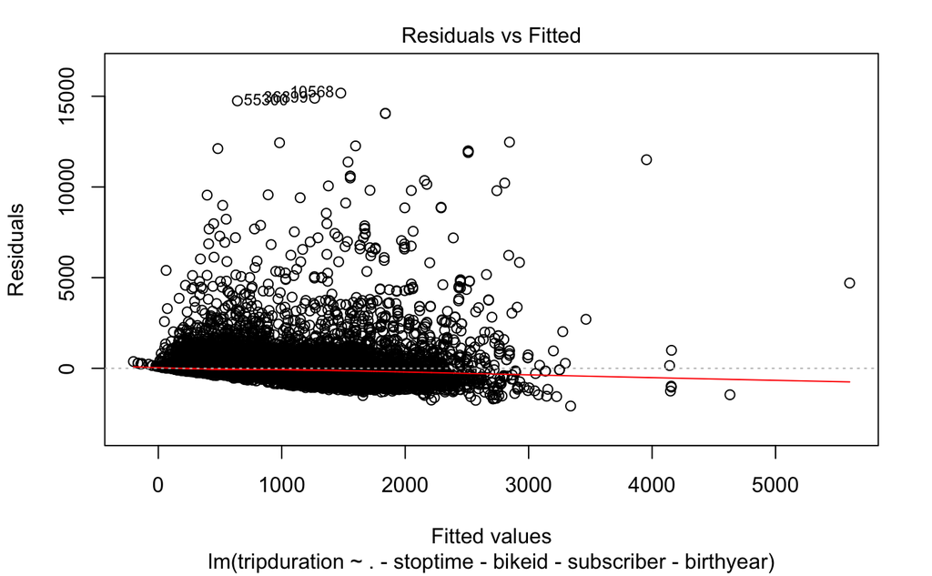

```r
plot(multlin, which = 1)
```

This plot shows that there is no distinct pattern along the horizontal line, which means this is not a bad model, as there is less likely to be non linear relationship that is not explained by the model.

Predicting the trip durations of the test data set

```r
removed <- c()
# Remove the cases from the testing set where the factors didn't exist in training (i.e. in testing set may be cases with station id 200, but these may not exist in the training
for (i in 1:ncol(test)) {
  if (is.factor(test[, i])) {
    for (j in 1:nrow(test)) {
      if (!(test[j, i] %in% train[, i])) {
        removed <- c(removed, j)
      }
    }
  }
}
```

```r
head(pred.test[, "tripduration"])
```

```
[1] 1935  302  341  636 1524  396
```

## Logistic Regression to predict whether a rider is a subscriber

```r
summary(logreg1)
```

```
Call:
glm(formula = subscriber ~ . - customer - stoptime - birthyear -
    bikeid, family = binomial(link = "logit"), data = train)

Deviance Residuals:
    Min       1Q   Median       3Q      Max
-4.8104   0.1286   0.2154   0.3260   6.4550

Coefficients:
                  Estimate Std. Error z value Pr(>|z|)
(Intercept)      9.468e+02  1.262e+03   0.750    0.453
starttime       -5.965e-07  2.912e-08 -20.482  < 2e-16 ***
startstation3   -2.547e+01  1.260e+03  -0.020    0.984
startstation4   -2.550e+01  1.260e+03  -0.020    0.984
startstation6   -2.489e+01  1.260e+03  -0.020    0.984
startstation7   -2.522e+01  1.260e+03  -0.020    0.984
startstation8   -2.467e+01  1.260e+03  -0.020    0.984
startstation9   -2.524e+01  1.260e+03  -0.020    0.984
startstation10  -2.523e+01  1.260e+03  -0.020    0.984
startstation11  -2.455e+01  1.260e+03  -0.019    0.984
startstation12  -2.490e+01  1.260e+03  -0.020    0.984
startstation14  -4.919e+00  1.309e+03  -0.004    0.997
startstation15  -2.453e+01  1.260e+03  -0.019    0.984
startstation16  -2.464e+01  1.260e+03  -0.020    0.984
startstation17  -2.541e+01  1.260e+03  -0.020    0.984
startstation19  -2.407e+01  1.260e+03  -0.019    0.985
startstation20  -2.582e+01  1.260e+03  -0.020    0.984
startstation21  -2.550e+01  1.260e+03  -0.020    0.984
startstation22  -2.483e+01  1.260e+03  -0.020    0.984
startstation23  -2.508e+01  1.260e+03  -0.020    0.984
startstation24  -2.495e+01  1.260e+03  -0.020    0.984
startstation25  -2.439e+01  1.260e+03  -0.019    0.985
startstation26  -2.405e+01  1.260e+03  -0.019    0.985
startstation27  -2.550e+01  1.260e+03  -0.020    0.984
startstation29  -2.506e+01  1.260e+03  -0.020    0.984
startstation30  -2.450e+01  1.260e+03  -0.019    0.984
startstation31  -2.497e+01  1.260e+03  -0.020    0.984
startstation33  -2.532e+01  1.260e+03  -0.020    0.984
startstation35  -2.475e+01  1.260e+03  -0.020    0.984
startstation36  -2.546e+01  1.260e+03  -0.020    0.984
```

[output cut: 293 more lines]

[output not shown]

This model shows that the startstation and endstation are not significant based on their p-values, and can be removed from the regression model

```r
logreg <- glm(subscriber ~ .-customer-stoptime-birthyear-bikeid-startstation-endstation, family=binomial(link='logit'),data=train)
summary(logreg)
```

```
Call:
glm(formula = subscriber ~ . - customer - stoptime - birthyear -
    bikeid - startstation - endstation, family = binomial(link = "logit"),
    data = train)

Deviance Residuals:
    Min       1Q   Median       3Q      Max
-3.0864   0.2012   0.2695   0.3376   6.7964

Coefficients:
               Estimate Std. Error z value Pr(>|z|)
(Intercept)   9.770e+02  4.331e+01  22.557  < 2e-16 ***
starttime    -6.399e-07  2.847e-08 -22.480  < 2e-16 ***
gender        1.975e-01  4.932e-02   4.005  6.2e-05 ***
tripduration -1.730e-03  3.693e-05 -46.848  < 2e-16 ***
gduration     1.121e-03  6.279e-05  17.851  < 2e-16 ***
---
Signif. codes:  0 ‘***’ 0.001 ‘**’ 0.01 ‘*’ 0.05 ‘.’ 0.1 ‘ ’ 1

(Dispersion parameter for binomial family taken to be 1)

    Null deviance: 23213  on 49138  degrees of freedom
Residual deviance: 18464  on 49134  degrees of freedom
AIC: 18474

Number of Fisher Scoring iterations: 6
```

This model shows that all the remaining parameters are significant in predicting whether a rider is a subscriber or casual customer, as shown by the p values, which are way below 0.05.

To evaluate this logistitic regression model, we run it on the testing set, and determine how often it is correct.

```r
prediction <- predict(logreg, newdata = test, type = 'response')
prediction <- ifelse(prediction >0.5, 1, 0)
accuracy <- mean(prediction != test$subscriber)
print(paste0((1 - accuracy) * 100, '%'))
```

```
[1] "94.1961741961742%"
```

This shows that the regression model is a good fit for the problem with a 94% accuracy in predicting whether one is a subscriber or not.

```r
table(Truth = test$subscriber, Prediction = prediction)
```

```
     Prediction
Truth     0     1
    0   111   660
    1    53 11461
```

```r
knntestpred <- knn(trainknn[, -6], testknn[, -6], trainknn$subscriber, k=sqrt(nrow(trainknn)))
```

Return the accuracy of the prediction

```r
accuracy <- mean(knntestpred != testknn$subscriber)
print(paste0((1 - accuracy) * 100, '%'))
```

```
[1] "94.3671143671144%"
```

With that k, the accuracy of the prediction is 94.36% Now to tune the model, we need to test different k values and find the optimal one. We test every k value that is smaller than the square root of number of observations.

```r
optimalk
```

```
[1] 5
```

This shows that the optimal k is 5, which results in the lowest error Now we have to evaluate the model and decide if it is accurate

```r
optimalknn <- knn(trainknn[, -6], testknn[, -6], trainknn$subscriber, k=5)
accuracyknn <- mean(optimalknn != testknn$subscriber)
print(paste0((1 - accuracyknn) * 100, '%'))
```

```
[1] "95.7183557183557%"
```

This shows that the kNN model is more accurate than the logistic regression in predicting whether a person is a subscriber or not.

```r
table(Truth = testknn$subscriber, Prediction = optimalknn)
```

```
     Prediction
Truth     0     1
    0   424   387
    1   139 11335
```

This shows that the kNN model has a bias toward false positives just like the logistic regression model, however, it is more accurate.

## Evaluation:

Between the kNN model and the logistic regression model to predict subscribers, the kNN model clearly is more accurate. However, to avoid mislabeling a subscriber as a customer, or vice versa, perhaps both should be looked at, with more weight put into kNN model.